# Lab 3 Assignment - Scale

Lucas Parvin

1-25-2024

## Challenge 1 (4 points)

**Build a raster with 100 rows and 100 columns. Fill the raster cells with values of a random variable drawn from a distribution of your choosing (Poisson, Normal, Uniform, etc.). Calculate the mean and variance of the values in that raster. Now increase the grain size of those cells by factors of 2, 5, and 10, combining cell values using a mean function. At each iteration, calculate the mean and variance of the values in the resulting raster. Generate 2 scatterplots that have grain size on the x-axis. Plot the mean raster value on the y-axis of the first, and variance on the y-axis of the second. What do you notice about how these values change as you “scale up” the grain size? Why do you think this pattern occurs?**

Place your code in the code chunk below so I can reproduce your analyses/figures.

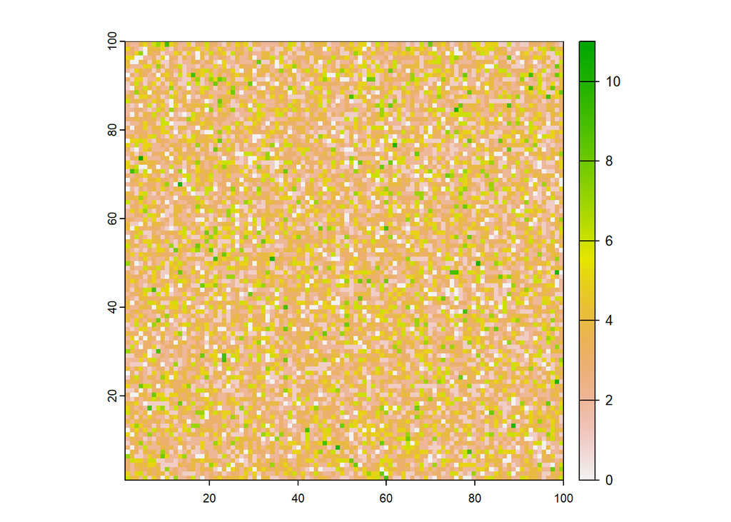

```r
#Load Packages

require(tidyverse)
require(sf)
require(AICcmodavg)
require(tigris)
require(FedData)
require(terra)
require(tidyterra)

#Build a raster with 100 rows and 100 columns.
simpRast = rast(ncol=100, nrow=100, xmin=1, xmax=100, ymin=1, ymax=100)

#Fill the raster cells with values of a random variable drawn from a distribution of your choosing (Poisson, Normal, Uniform, etc.).
set.seed(23)
simpRast[] = rpois(ncell(simpRast), lambda=3)
plot(simpRast)
```

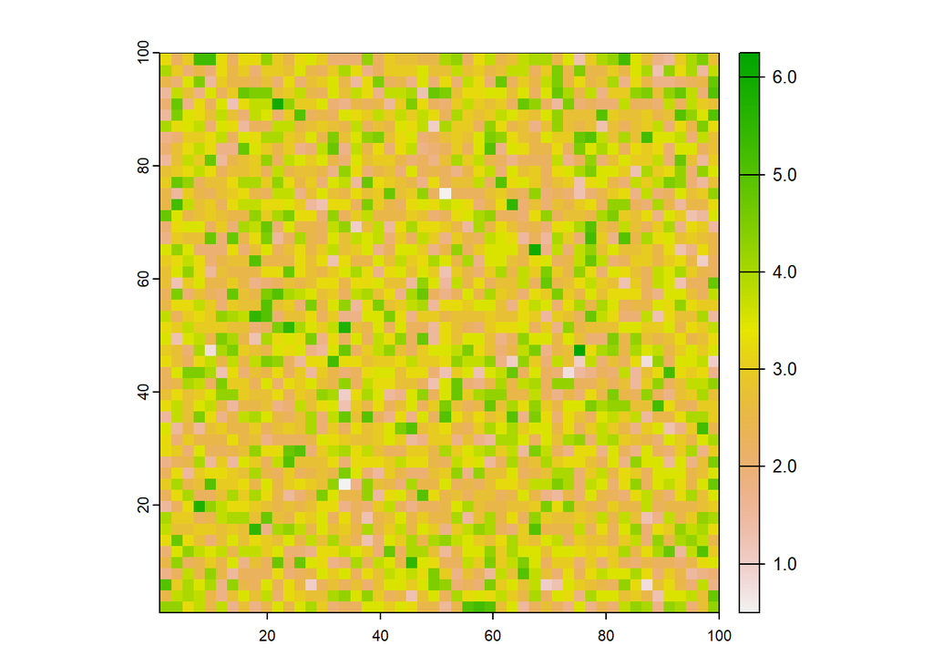

```r
#Calculate the mean and variance of the values in that raster.
orig_mean <- global(simpRast, mean)
orig_var <- global(simpRast, var)

#Now increase the grain size of those cells by factors of 2, 5, and 10, combining cell values using a mean function. At each iteration, calculate the mean and variance of the values in the resulting raster.

# By 2
simpRastMean2 <- aggregate(simpRast, fact=2, fun='mean')
plot(simpRastMean2)
```

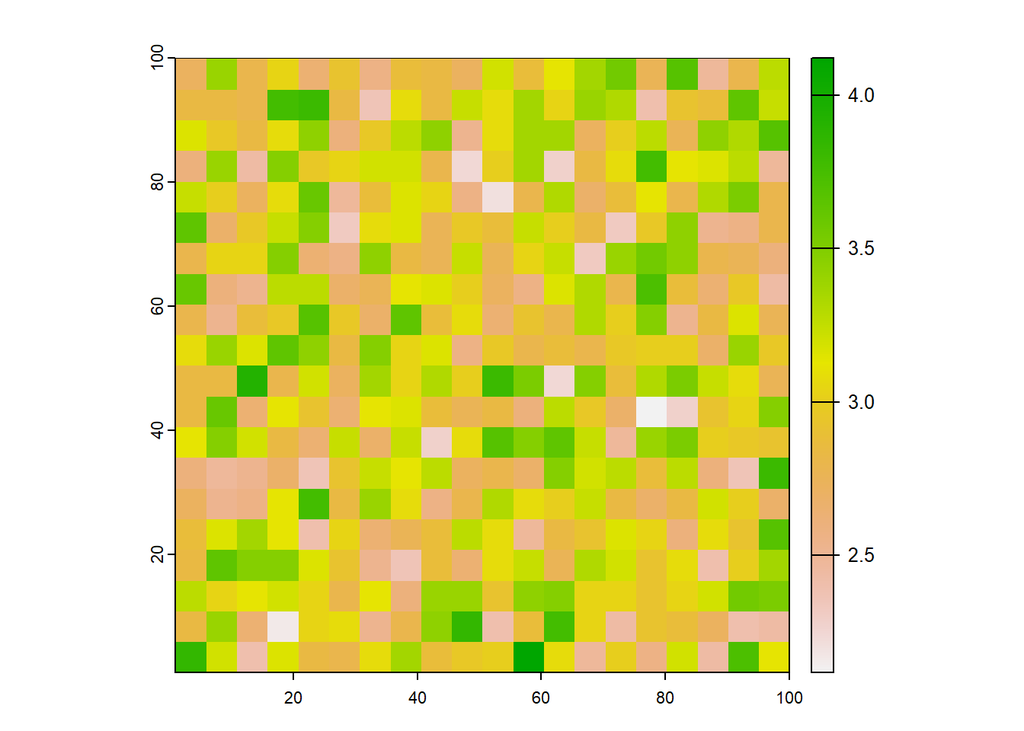

```r
x2_mean <- global(simpRastMean2, mean)
x2_var <- global(simpRastMean2, var)

# By 5
simpRastMean5 <- aggregate(simpRast, fact=5, fun='mean')
plot(simpRastMean5)
```

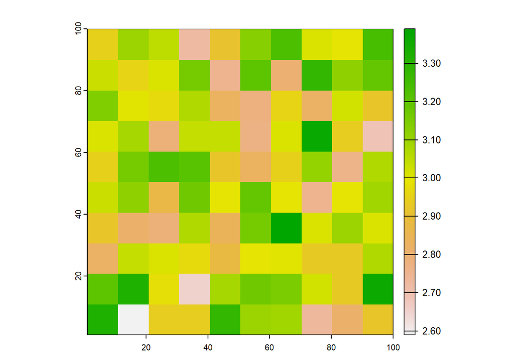

```r
x5_mean <- global(simpRastMean5, mean)
x5_var <- global(simpRastMean5, var)

# By 10
simpRastMean10 <- aggregate(simpRast, fact=10, fun='mean')
plot(simpRastMean10)
```

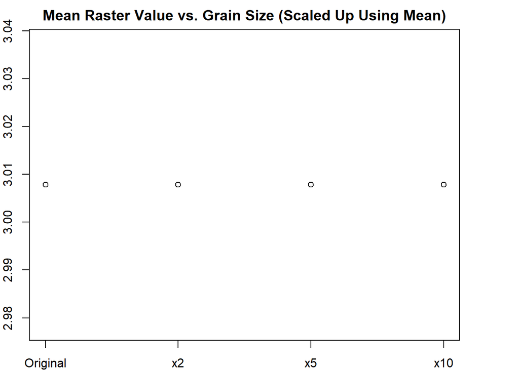

```r
x10_mean <- global(simpRastMean10, mean)
x10_var <- global(simpRastMean10, var)

# Generate 2 scatterplots that have grain size on the x-axis. Plot the mean raster value on the y-axis of the first, and variance on the y-axis of the second.

grain_size <- c("Original", "x2", "x5", "x10")
variances <- c(orig_var, x2_var, x5_var, x10_var)
means <- c(orig_mean, x2_mean, x5_mean, x10_mean)

# Convert grain size to a numeric scale for plotting
numeric_grain_size <- as.numeric(factor(grain_size, levels = grain_size))

# Plot for Mean Raster Value
plot(numeric_grain_size, means,
     xaxt = 'n', # Turn off x-axis labels
     xlab = "Grain Size",
     ylab = "Mean Raster Value",
     main = "Mean Raster Value vs. Grain Size (Scaled Up Using Mean)")

# Add custom x-axis labels
axis(1, at = numeric_grain_size, labels = grain_size)
```

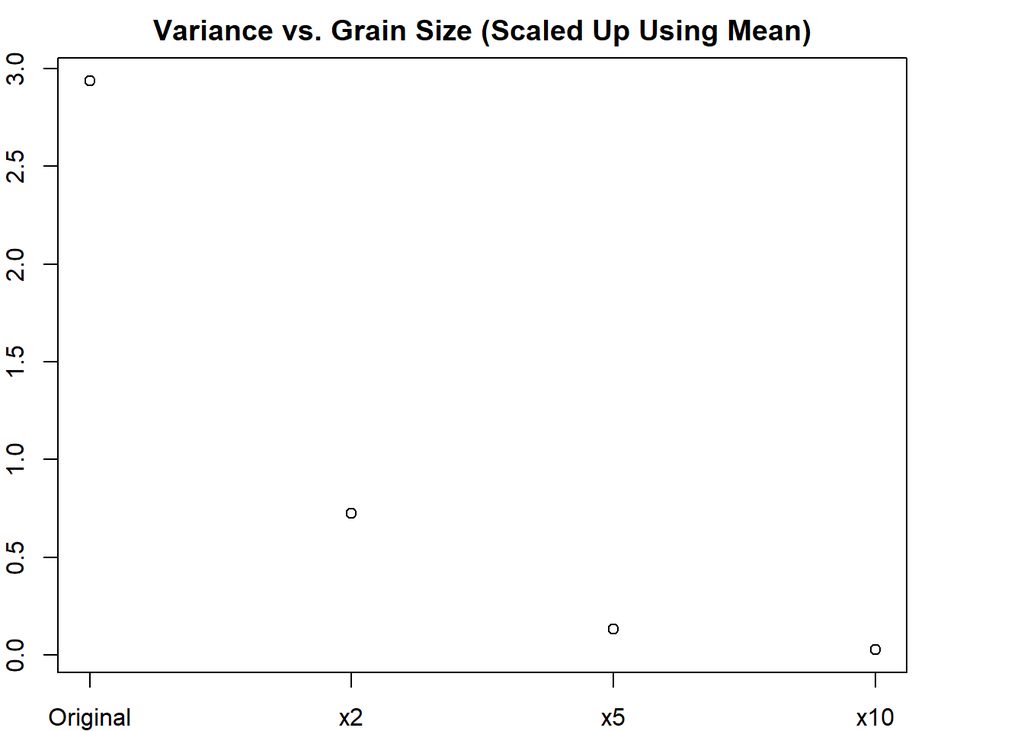

```r
# Plot for Variance
plot(numeric_grain_size, variances,
     xaxt = 'n', # Turn off x-axis labels
     xlab = "Grain Size",
     ylab = "Variance",
     main = "Variance vs. Grain Size (Scaled Up Using Mean)")

# Add custom x-axis labels
axis(1, at = numeric_grain_size, labels = grain_size)
```

## Challenge 2 (4 points)

**Identify a situation in which you might use a summary function other than the mean to calculate new cell values when you scale up the grain of a raster (e.g., median, mode, minimum, maximum, etc.). Repeat the effort from Challenge 1 using this alternate function. Again, create two scatterplots showing how the mean and variance values of the raster change as you scale up the cell size by factors of 2, 5, and 10. Do you see a similar pattern? Compare and contrast your findings with those from Challenge 1.**

*Hint: You should be able to recycle your code from Challenge 1 with only a couple of small tweaks to answer this question.*

Place your code in the code chunk below so I can reproduce your analyses/figures.

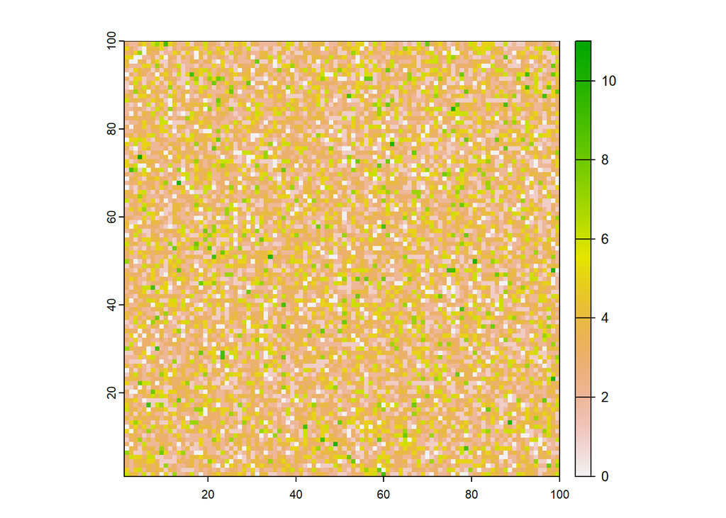

```r
#Build a raster with 100 rows and 100 columns.
simpRast2 = rast(ncol=100, nrow=100, xmin=1, xmax=100, ymin=1, ymax=100)

#Fill the raster cells with values of a random variable drawn from a distribution of your choosing (Poisson, Normal, Uniform, etc.).
set.seed(23)
simpRast2[] = rpois(ncell(simpRast), lambda=3)
plot(simpRast2)
```

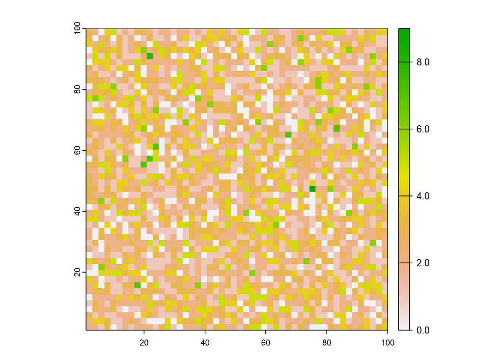

```r
#Calculate the mean and variance of the values in that raster.
orig_mean2 <- global(simpRast2, mean)
orig_var2 <- global(simpRast2, var)

#Now increase the grain size of those cells by factors of 2, 5, and 10, combining cell values using a mean function. At each iteration, calculate the mean and variance of the values in the resulting raster.

# By 2
simpRastMode2 <- aggregate(simpRast2, fact=2, fun='modal')
plot(simpRastMode2)
```

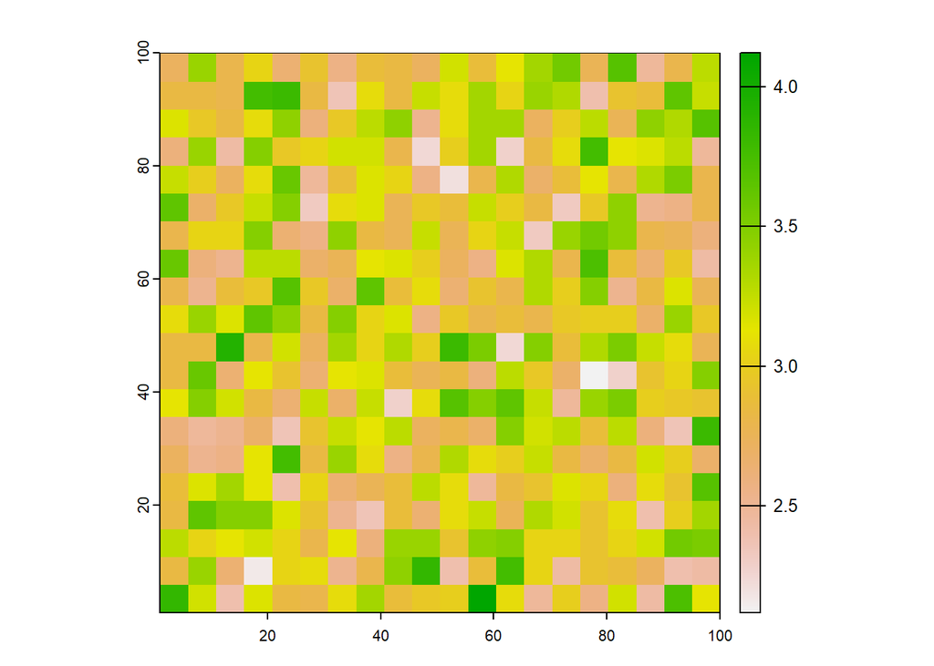

```r
x2_mean2 <- global(simpRastMode2, mean)
x2_var2 <- global(simpRastMode2, var)

# By 5
simpRastMode5 <- aggregate(simpRast2, fact=5, fun='modal')
plot(simpRastMean5)
```

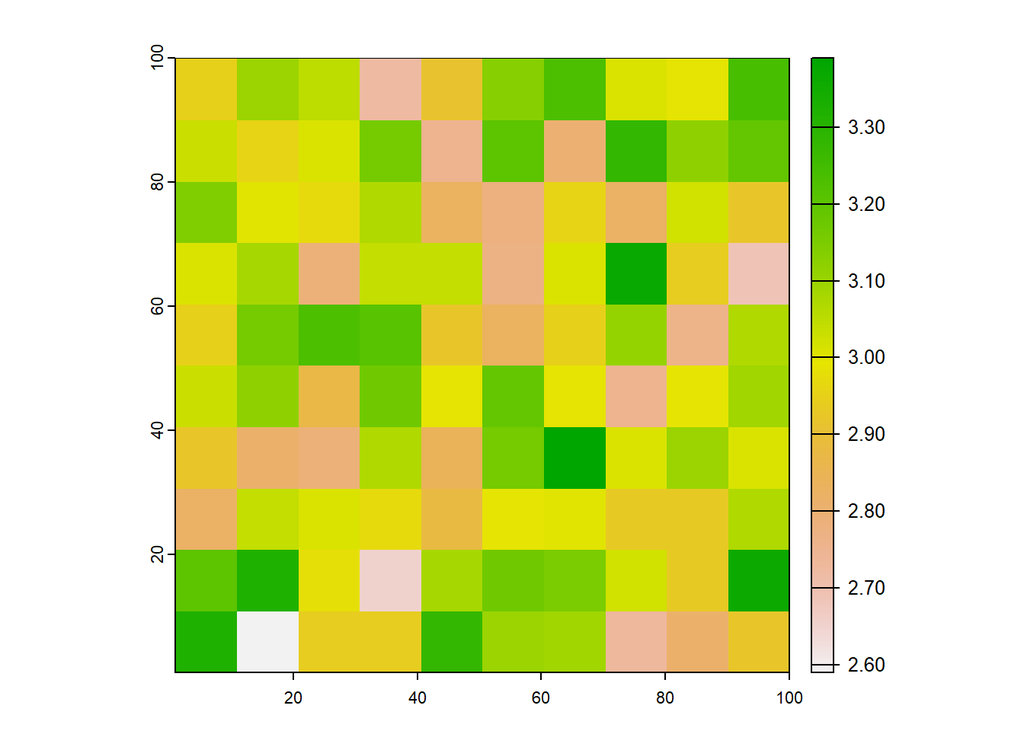

```r
x5_mean2 <- global(simpRastMode5, mean)
x5_var2 <- global(simpRastMode5, var)

# By 10
simpRastMode10 <- aggregate(simpRast2, fact=10, fun='modal')
plot(simpRastMean10)
```

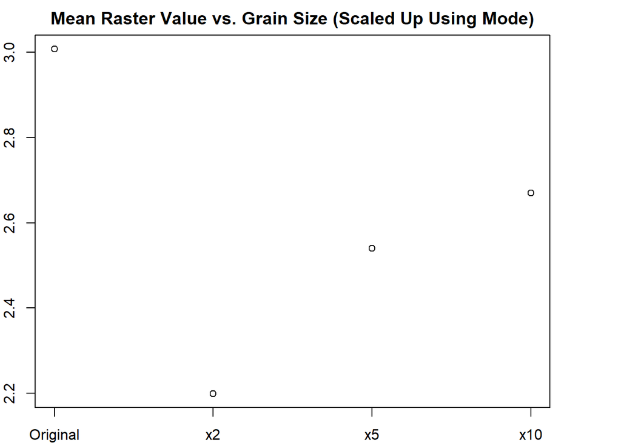

```r
x10_mean2 <- global(simpRastMode10, mean)
x10_var2 <- global(simpRastMode10, var)

# Generate 2 scatterplots that have grain size on the x-axis. Plot the mean raster value on the y-axis of the first, and variance on the y-axis of the second.

grain_size2 <- c("Original", "x2", "x5", "x10")
variances2 <- c(orig_var2, x2_var2, x5_var2, x10_var2)
means2 <- c(orig_mean2, x2_mean2, x5_mean2, x10_mean2)

# Convert grain size to a numeric scale for plotting
numeric_grain_size2 <- as.numeric(factor(grain_size2, levels = grain_size2))

# Plot for Mean Raster Value
plot(numeric_grain_size2, means2,
     xaxt = 'n', # Turn off x-axis labels
     xlab = "Grain Size",
     ylab = "Mean Raster Value",
     main = "Mean Raster Value vs. Grain Size (Scaled Up Using Mode)")

# Add custom x-axis labels
axis(1, at = numeric_grain_size2, labels = grain_size2)
```

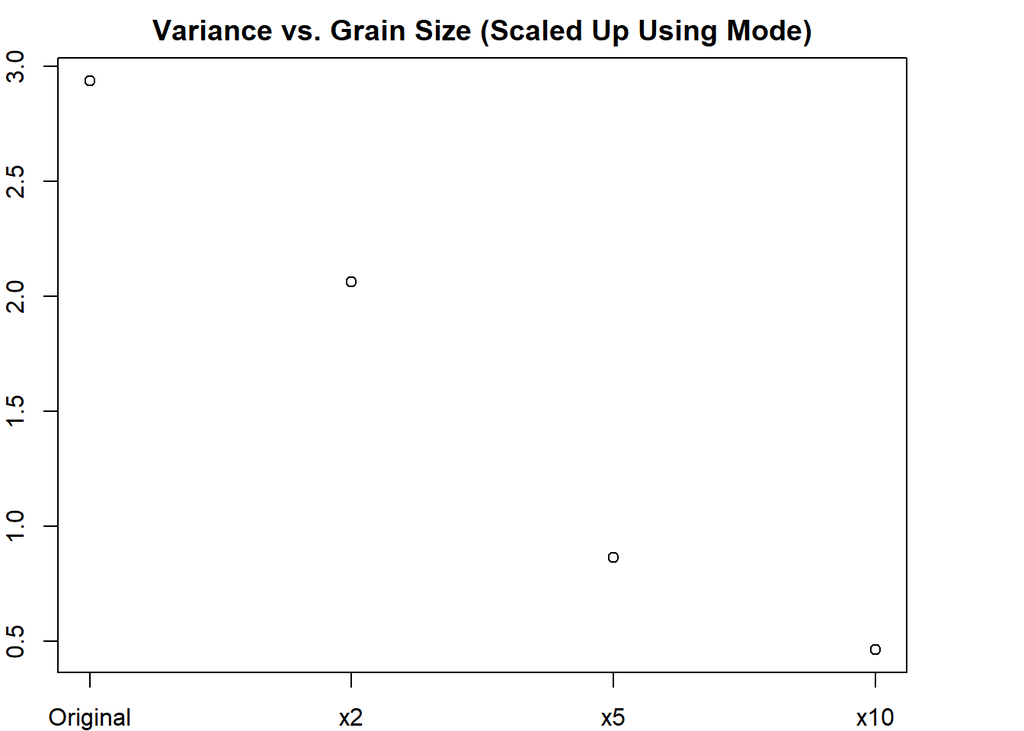

```r
# Plot for Variance
plot(numeric_grain_size2, variances2,
     xaxt = 'n', # Turn off x-axis labels
     xlab = "Grain Size",
     ylab = "Variance",
     main = "Variance vs. Grain Size (Scaled Up Using Mode)")

# Add custom x-axis labels
axis(1, at = numeric_grain_size2, labels = grain_size2)
```

**ANSWER:** A situation in which I would use a summary function other than mean to calculate new cell values when scaling up would be when dealing with values that represent categorical variables. For example, in this scenario, each whole number could represent a different land cover type, and thus finding the average of two cell types to form a new value would not be appropriate. Instead, I will take the mode of cell values so that the larger grains are represented by the most prominent land cover values that previously occupied the smaller grains.

After increasing grain size by a factor of two using a modal approach, the mean dropped from ~3 to ~2.2. However, when increasing grain by factors fo 5 and 10, the mean raster values increased again to ~2.55 and ~2.7, seemingly approaching 3, the true mean (which originally should also be the most common land cover type). Thus, with this limited sample size, it appears there is an initial destabilization/skew regarding how the mean changes with a modal approach. Furthermore, it appears that when scaling up by a factor of 2, if 4 pixels contain separate values, the new pixel or grain will assume the lowest value, which would explain the the initial drop in mean, which later seems to stabilize. This contrasts with the findings from Challenge 1, in which the mean remained constant across grain sizes.

Variance on the other hand followed a very similar trajectory to that of Challenge 1. As grain sizes increased, variance dropped rapidly. This also makes sense to me, given that with each iteration, by reducing the number of pixels to one value, I am inherently altering the potential for variance. For example, when scaling up by a factor of 2, one cluster of pixels being scaled up could have the values, 1, 2, 4, and 4. Of course, in a vacuum, these values will have more variance than the single value (4) that will result after, given that a single value has no variance. Thus, by aggregating data using either the mean (Challenge 1) or mode (Challenge 2), I am smoothing out variation and decreasing the measure of variance.

## Challenge 3 (2 points)

**Recall that before we calculated forest cover, we cropped our NLCD raster to minimize its size and the computing effort necessary from our poor little computers. How might that affect our ability to evaluate the scale at which five-lined skinks respond to forest cover? Why?**

**ANSWER:** By cropping our NLCD raster, we have set a maximum limit for the scale at which we can evaluate skink response to forest cover. IF we don’t have land cover data for anything beyond the bounds we have set, then evaluating skink response to unknown cover extending beyond those bounds is not appropriate. Ultimately, you have to obtain data at the appropriate scales to evaluate response at the appropriate scales. Hypothetically, if we had land over for the entire planet, there is no reason why we couldn’t model skink response to forest cover on a global scale.

## Challenge 4 (4 points)

**In the lab, we measured forest cover at 1 km and 5 km. Extract forest cover proportions around each sample point for 100 m, 500 m, 1 km, 2 km, 3 km, 4 km, and 5 km scales. Examine the correlation between these 7 variables (remember the chart.Correlation() function). What patterns do you notice in correlation among these variables?**

*Hint: Recall the for loop we used to calculate this variable at two scales… could you make a small addition here to look at more scales?*

```r
sites = st_read("/vsicurl/https://github.com/ValenteJJ/SpatialEcology/raw/main/Week3/reptiledata.shp") %>%
  filter(management!='Corn')
st_crs(sites) = "+proj=aea +lat_0=23 +lon_0=-96 +lat_1=29.5 +lat_2=45.5 +x_0=0 +y_0=0 +datum=NAD83 +units=m +no_defs"
head(sites)
```

|  | site | management | coords_x1 | coords_x2 | geometry |
| --- | --- | --- | --- | --- | --- |
| 1 | AL1 | Reference | 846279.4 | 921444.9 |  |
| 2 | AL10 | Clear cut, residues removed | 899063.5 | 989168.9 |  |
| 3 | AL11 | Young, Managed | 898755.1 | 990398.2 |  |
| 4 | AL12 | Old, managed | 867689.7 | 1007135.9 |  |
| 5 | AL13 | Clear cut, residues removed | 868534.7 | 1001561.4 |  |
| 6 | AL14 | Unthinned, Managed | 867288.2 | 1006417.8 |  |

```r
states = states() %>%
  filter(NAME %in% c('Alabama', 'Florida', 'Georgia')) %>%
  st_transform(crs(sites, proj=T))
```

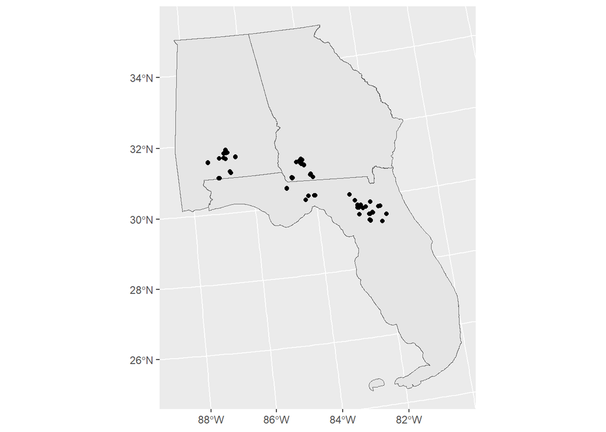

```r
ggplot()+
  geom_sf(data = states)+
  geom_sf(data = sites)
```

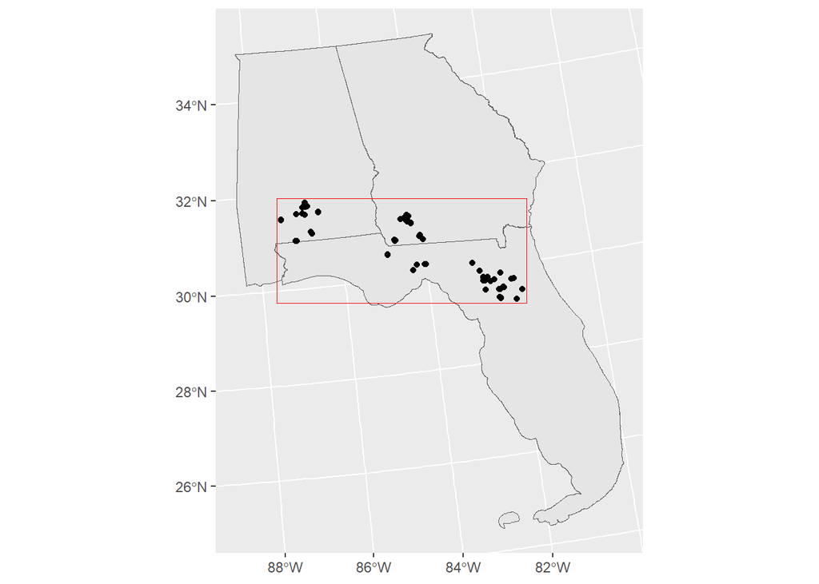

```r
presAbs = read.csv('https://raw.githubusercontent.com/ValenteJJ/SpatialEcology/main/Week3/reptiles_flsk.csv')

sites = sites %>%
  left_join(presAbs, by='site')

#Extract x and y coordinates of the bounding box
studyArea = st_bbox(sites) + c(-10000, -10000, 10000, 10000)
studyArea = st_as_sfc(studyArea)


ggplot()+
  geom_sf(data = states)+
  geom_sf(data = studyArea, fill=NA, color='red')+
  geom_sf(data = sites)
```

```r
nlcd = get_nlcd(studyArea,
                label='studyArea',
                year = 2016,
                dataset = 'landcover',
                landmass = 'L48'
)
```

```
##
|---------|---------|---------|---------|
=========================================
```

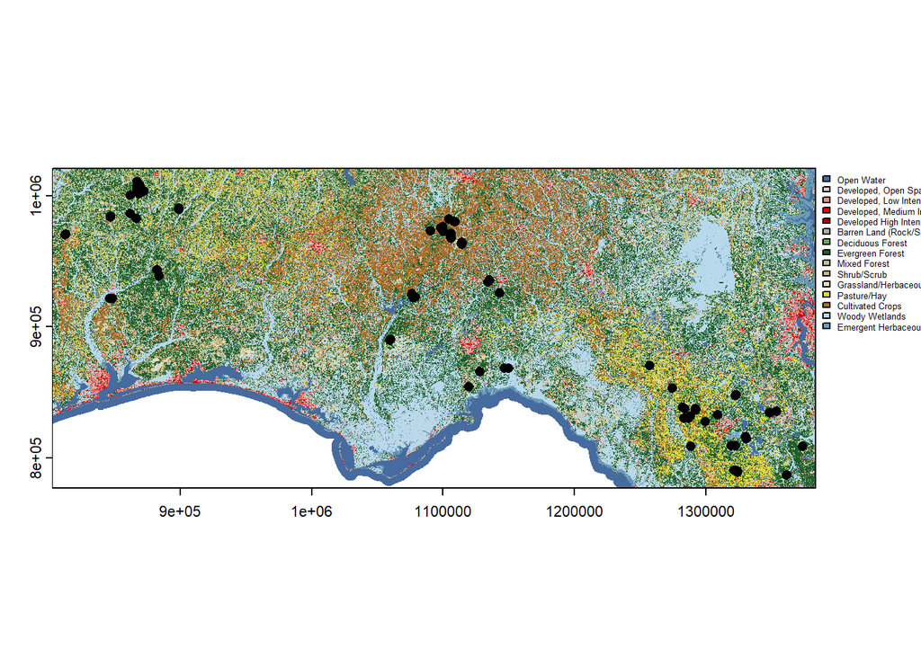

```r
plot(nlcd, 1, legend=T, plg=list(cex=0.5))
plot(st_geometry(sites), add=T, pch=16)
```

```r
forest = nlcd %>%
  setValues(0)
```

```
##
|---------|---------|---------|---------|
=========================================
```

```r
forest[nlcd=='Deciduous Forest' | nlcd=='Evergreen Forest' | nlcd=='Mixed Forest'] = 1
```

[output not shown]

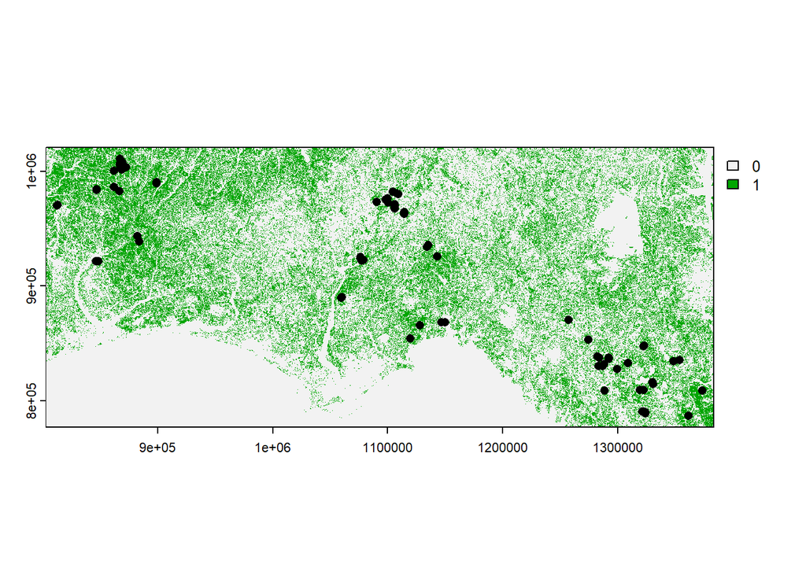

```r
plot(forest)
plot(st_geometry(sites), add=T, pch=16, col='black')
```

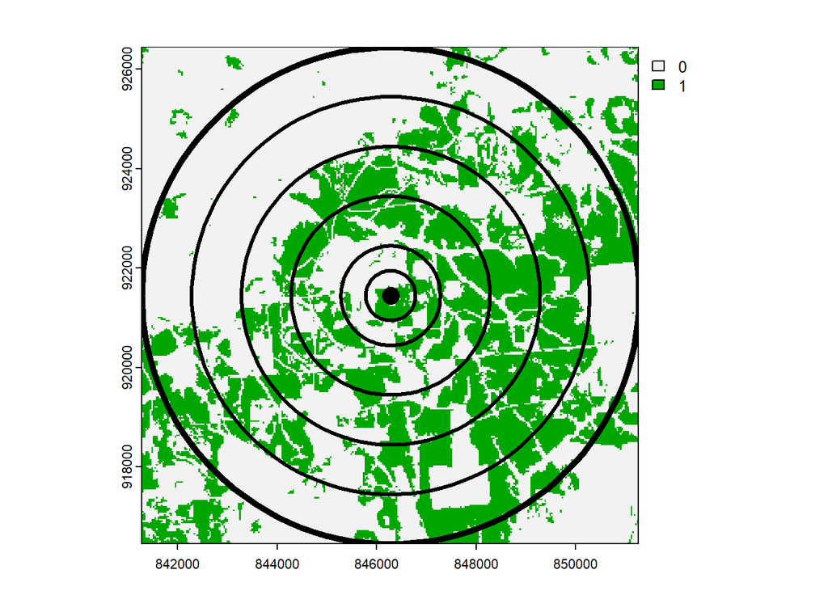

```r
#Extract forest cover proportions around each sample point for 100 m, 500 m, 1 km, 2 km, 3 km, 4 km, and 5 km scales


buffSite100m = st_buffer(sites[1,], dist=100)
buffSite500m = st_buffer(sites[1,], dist=500)
buffSite1km = st_buffer(sites[1,], dist=1000)
buffSite2km = st_buffer(sites[1,], dist=2000)
buffSite3km = st_buffer(sites[1,], dist=3000)
buffSite4km = st_buffer(sites[1,], dist=4000)
buffSite5km = st_buffer(sites[1,], dist=5000)


zoom(forest, buffSite5km)
plot(st_geometry(buffSite5km), border='black', lwd=5, add=T)
plot(st_geometry(buffSite4km), border='black', lwd=3, add=T)
plot(st_geometry(buffSite3km), border='black', lwd=3, add=T)
plot(st_geometry(buffSite2km), border='black', lwd=3, add=T)
plot(st_geometry(buffSite1km), border='black', lwd=3, add=T)
plot(st_geometry(buffSite500m), border='black', lwd=3, add=T)
plot(st_geometry(buffSite100m), border='black', lwd=3, add=T)
plot(st_geometry(sites[1,]), pch=16, cex=2, color='black', add=T)
```

```r
bufferCover = function(shp, size, landcover){
  buffArea = (pi*size^2)/10000
  grainArea = (prod(res(landcover)))/10000

  buffi = st_buffer(shp[i,], dist=size)
  cropi = crop(landcover, buffi, mask=T)
  numCells = global(cropi, 'sum', na.rm=T)
  forestHa = numCells * grainArea
  propForest = forestHa / buffArea

  return(propForest)
}


#This is where we are going to store the output values

for100m = as.vector(rep(NA, nrow(sites)))
for500m = as.vector(rep(NA, nrow(sites)))
for1km = as.vector(rep(NA, nrow(sites)))
for2km = as.vector(rep(NA, nrow(sites)))
for3km = as.vector(rep(NA, nrow(sites)))
for4km = as.vector(rep(NA, nrow(sites)))
for5km = as.vector(rep(NA, nrow(sites)))

for(i in 1:nrow(sites)){
  for100m[i] = bufferCover(sites, 100, forest)
  for500m[i] = bufferCover(sites, 500, forest)
  for1km[i] = bufferCover(sites, 1000, forest)
  for2km[i] = bufferCover(sites, 2000, forest)
  for3km[i] = bufferCover(sites, 3000, forest)
  for4km[i] = bufferCover(sites, 4000, forest)
  for5km[i] = bufferCover(sites, 5000, forest)
}

forestData = sites %>%
  mutate(for100m = unlist(for100m),
         for500m = unlist(for500m),
         for1km = unlist(for1km),
         for2km = unlist(for2km),
         for3km = unlist(for3km),
         for4km = unlist(for4km),
         for5km = unlist(for5km))

head(forestData)
```

|  | site | management | coords_x1 | coords_x2 | pres | geometry | for100m | for500m | for1km | for2km | for3km | for4km | for5km |
| --- | --- | --- | --- | --- | --- | --- | --- | --- | --- | --- | --- | --- | --- |
| 1 | AL1 | Reference | 846279.4 | 921444.9 | 1 |  | 1.14591559 | 0.5729578 | 0.3701307 | 0.4984017 | 0.5110784 | 0.4610878 | 0.3861506 |
| 2 | AL10 | Clear cut, residues removed | 899063.5 | 989168.9 | 0 |  | 0.05729578 | 0.7505747 | 0.8247727 | 0.6897696 | 0.6278981 | 0.6270844 | 0.6280420 |
| 3 | AL11 | Young, Managed | 898755.1 | 990398.2 | 0 |  | 1.05997192 | 0.9465263 | 0.7812280 | 0.7154094 | 0.6965894 | 0.6538344 | 0.6579389 |
| 4 | AL12 | Old, managed | 867689.7 | 1007135.9 | 1 |  | 1.23185926 | 0.8525612 | 0.7004409 | 0.6637000 | 0.6728116 | 0.6436465 | 0.6306088 |
| 5 | AL13 | Clear cut, residues removed | 868534.7 | 1001561.4 | 1 |  | 1.17456348 | 0.8857928 | 0.7462775 | 0.7512909 | 0.7717423 | 0.7389902 | 0.7042683 |
| 6 | AL14 | Unthinned, Managed | 867288.2 | 1006417.8 | 0 |  | 0.05729578 | 0.2131403 | 0.4365938 | 0.6576123 | 0.6750716 | 0.6609784 | 0.6573086 |

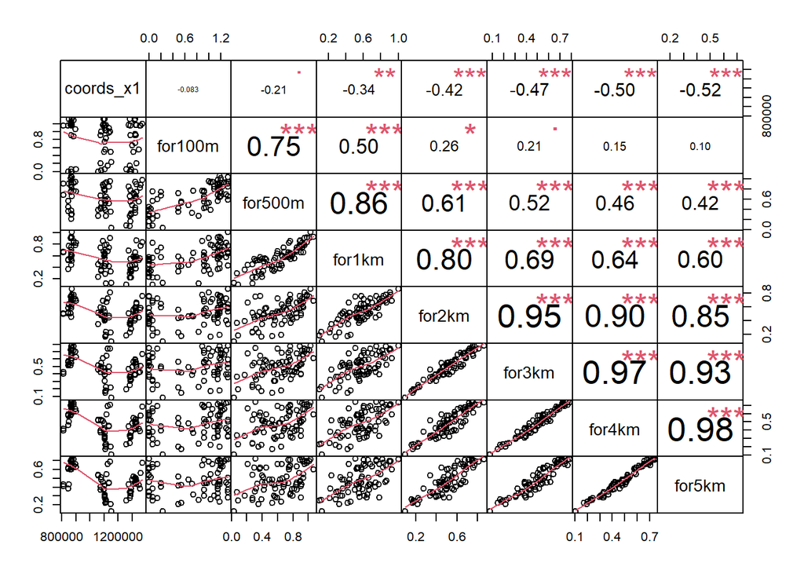

```r
forestData %>%
  as.data.frame() %>%
  select(coords_x1, for100m, for500m, for1km, for2km, for3km, for4km, for5km) %>%
  PerformanceAnalytics::chart.Correlation(histogram=F)
```

**ANSWER:** As is to be expected, the correlation between variables decreases with relative distance. For example, the amount of tree cover in a 5 km radius is highly correlated with the amount of tree cover in a 4 km radius, but not at all with the amount of tree cover in a 100 m radius.

## Challenge 5 (4 points)

**Fit 8 logistic regression models (a null model and one for each of the 7 forest scales). Compare these models using AICc. Which scale do you think represents the critical or characteristic scale at which forest cover affects skink presence? Is this scale clearly better than the others, or is there some ambiguity? What are some mechanisms by which forest cover could affect skink presence at this scale? What is your overall conclusion regarding how forest cover affects skink presence (i.e., take a look at the betas)?**

Place your R code in the chunk below.

```r
modelNull = glm(pres~1, family='binomial', data=forestData)
model100m = glm(pres~for100m, family='binomial', data=forestData)
model500m = glm(pres~for500m, family='binomial', data=forestData)
model1km = glm(pres~for1km, family='binomial', data=forestData)
model2km = glm(pres~for2km, family='binomial', data=forestData)
model3km = glm(pres~for3km, family='binomial', data=forestData)
model4km = glm(pres~for4km, family='binomial', data=forestData)
model5km = glm(pres~for5km, family='binomial', data=forestData)


aictab(list(modelNull, model100m, model500m, model1km, model2km, model3km, model4km, model5km), modnames=c('Null', '100 m', '500 m', '1 km', '2 km', '3 km', '4 km', '5 km'))
```

|  | Modnames | K | AICc | Delta_AICc | ModelLik | AICcWt | LL | Cum.Wt |
| --- | --- | --- | --- | --- | --- | --- | --- | --- |
| 5 | 2 km | 2 | 67.09563 | 0.0000000 | 1.000000e+00 | 3.627475e-01 | -31.46782 | 0.3627475 |
| 7 | 4 km | 2 | 67.45459 | 0.3589543 | 8.357071e-01 | 3.031507e-01 | -31.64729 | 0.6658982 |
| 6 | 3 km | 2 | 68.63975 | 1.5441209 | 4.620600e-01 | 1.676111e-01 | -32.23988 | 0.8335093 |
| 8 | 5 km | 2 | 68.68018 | 1.5845484 | 4.528138e-01 | 1.642571e-01 | -32.26009 | 0.9977664 |
| 4 | 1 km | 2 | 77.39862 | 10.3029846 | 5.790757e-03 | 2.100583e-03 | -36.61931 | 0.9998670 |
| 3 | 500 m | 2 | 83.37176 | 16.2761252 | 2.922028e-04 | 1.059958e-04 | -39.60588 | 0.9999730 |
| 2 | 100 m | 2 | 86.76038 | 19.6647460 | 5.368521e-05 | 1.947418e-05 | -41.30019 | 0.9999925 |
| 1 | Null | 1 | 88.66111 | 21.5654777 | 2.075468e-05 | 7.528708e-06 | -43.30424 | 1.0000000 |

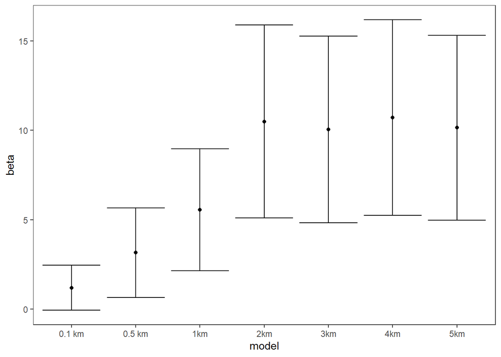

```r
effects = data.frame(model = c('0.1 km', '0.5 km', '1km', '2km', '3km', '4km', '5km'),
           beta = c(summary(model100m)$coefficients[2,1], summary(model500m)$coefficients[2,1],
                    summary(model1km)$coefficients[2,1], summary(model2km)$coefficients[2,1],
                    summary(model3km)$coefficients[2,1], summary(model4km)$coefficients[2,1],
                    summary(model5km)$coefficients[2,1]),
           se = c(summary(model100m)$coefficients[2,2], summary(model500m)$coefficients[2,2],
                    summary(model1km)$coefficients[2,2], summary(model2km)$coefficients[2,2],
                    summary(model3km)$coefficients[2,2], summary(model4km)$coefficients[2,2],
                    summary(model5km)$coefficients[2,2]))

effects = effects %>%
  mutate(lcl = beta - 1.96*se,
         ucl = beta + 1.96*se)

ggplot(effects, aes(x=model))+
  theme_bw()+
  theme(panel.grid=element_blank())+
  geom_point(aes(y=beta))+
  geom_errorbar(aes(ymin=lcl, ymax=ucl))
```

**ANSWER:** Comparison of the models suggests that skink presence is best predicted by forest cover at the 2 km scale. However, the model that operates on a 4 km scale has an extremely similar Delta_AICc value, while the 3 km and 5 km models also have Delta_AICc values of less than or equal to 1.58. Given that any models with values between 0 and 2 have “substantial support,” all 4 of these models are highly predictive. Further ambiguity is introduced by the fact that the best model is 2 km, followed by 4 km, and then 3 km and 5 km. If 2 km model represented the clear characteristic scale, I would expect 1 km or 3 km to be the next best, not 4 km. Thus, the characteristic scale seems to fall between 2 and 5 km, but at those levels, the exact critical value seems vague.

The beta values for each 2, 3, 4, and 5 km models are all very close to one another (~10). Given that skink presence is not well predicted by forest cover anywhere within 1 km and that skinks likely don’t cover territories that large given their size, I would guess that the mechanism by which forest cover is positively affecting skink presence at the 2, 3, 4, and 5 km scales is related to prey availability and not habitat. Skinks likely feed on invertebrates (including winged-insects with larger foraging ranges) that require proximity to forests for resources and cover, but also probably benefit from nesting in more open sandy areas conducive to burrow-building and basking in the sun. Of course, there are a lot of assumptions in this explanation and I know next to nothing about skinks.

## Challenge 6 (2 points)

**If you encounter ambiguity in identifying the characteristic scale of an effect, can you come up with a clever way to condense the information in the multi-scale variables into just one or two? When might it be ok to include two covariates in the same model (think multiple regression) that represent the same ecological feature measured at different scales (e.g., forest cover at 1 km AND forest cover at 5 km in the same model)? I can think of both a biological and a statistical answer to this question.**

**ANSWER:** Statistical: If you have multiple variables representing the same feature at different scales, you can employ a Principal Component Analysis to condense these into a smaller set of uncorrelated principal components. These components can capture variance across scales in a more condensed form, thus eliminating the need to use each individual variable.

Furthermore, if two covariates representing the same ecological features at different scales are NOT statistically correlated with one another, then I would assume including them in the same multiple-linear regression should not be an issue because both might provide unique information without introducing collinearity concerns.

Biological: If different scales capture distinct ecological processes or interactions, it might be meaningful to include them. For example, forest cover at 500 m might influence local habitat conditions, while forest cover at 5 km might reflect broader landscape connectivity. However, in some cases, from a biological perspective, if you find that covariates representing the same ecological features are highly statistically correlated with one another, such as 4 km and 5 km forest cover, then you can confidently assume they are essentially capturing the same ecological interactions – thus, they don’t both need to be included.